# 心理ネットワークアプローチ

## 中心性の比較

```r
centralityPlot(results_dep, include = "Strength")
centralityPlot(results_dep2, include = "Strength")
```

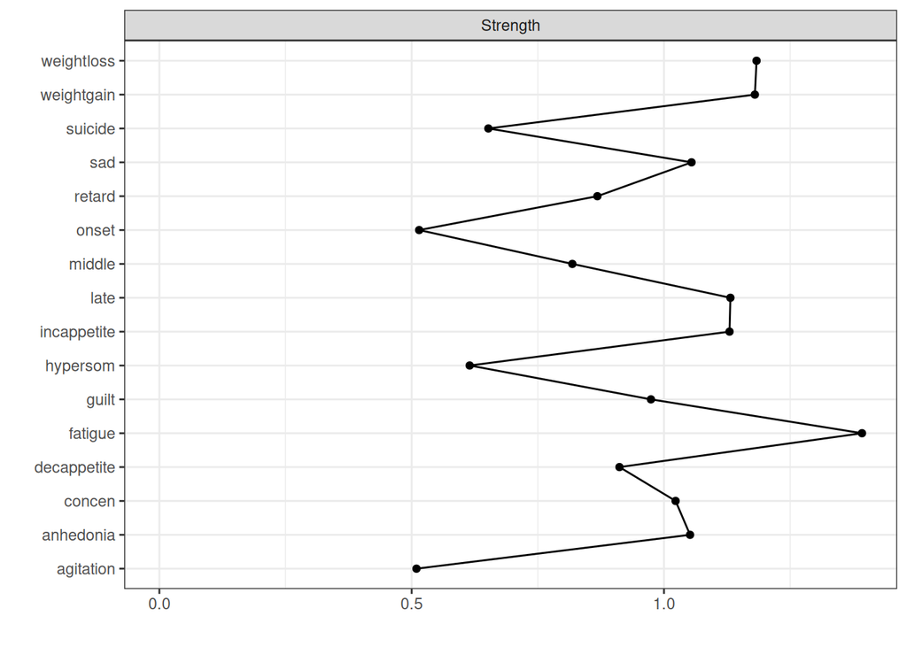

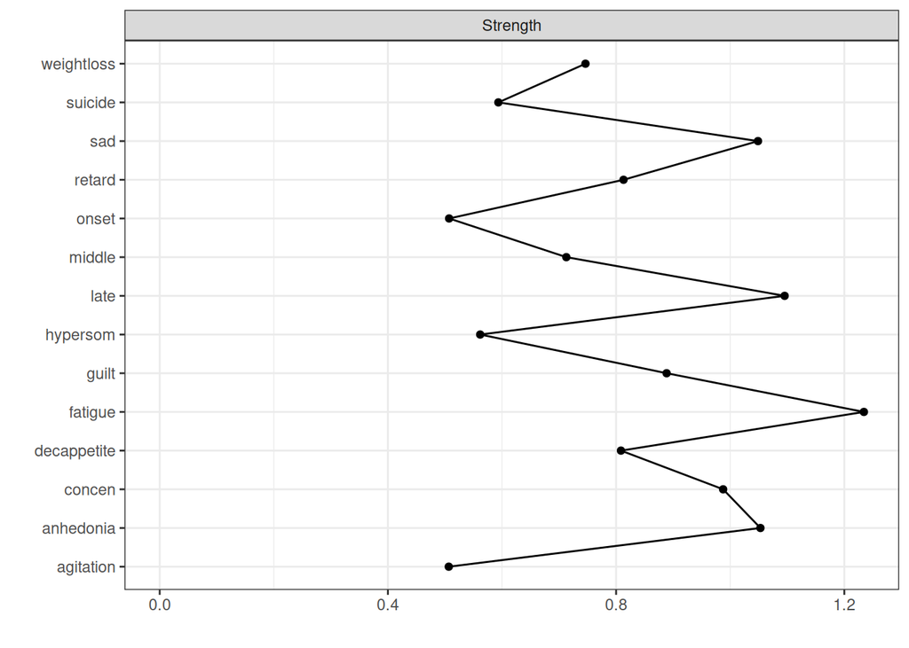

- ２変数の除外により（右図）、weightloss（体重減少）のStrengthが下がる

## Expected Influence(EI)

- Strengthがエッジの重みの「絶対値」の合計であるのに対し、EIは正（促進）と負（抑制）のエッジの重みをそのまま合計したもの
- 正と負が明確になり、あるノードがネットワーク全体を活性化させるのか、非活性化させるのかが分かる
- EIには１ステップと２ステップがある。1ステップはStrengthと同じく直接的接続を扱い、2ステップは2ステップ先までの間接的接続を扱う

```r
ei_results <- expectedInf(results_dep$graph)
plot(ei_results)
```

## EIの１ステップと２ステップ

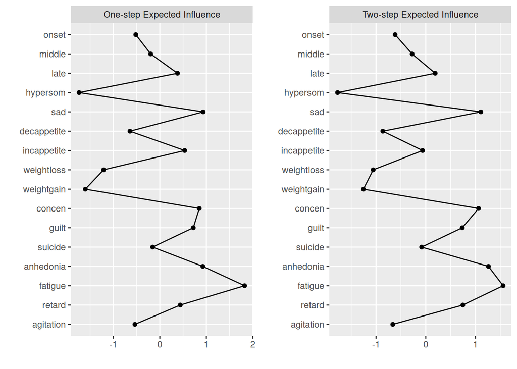

## EIとストレングスの比較

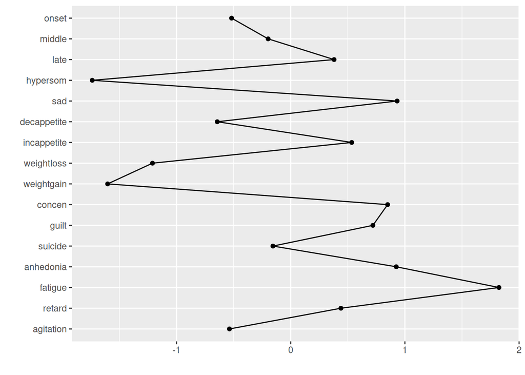

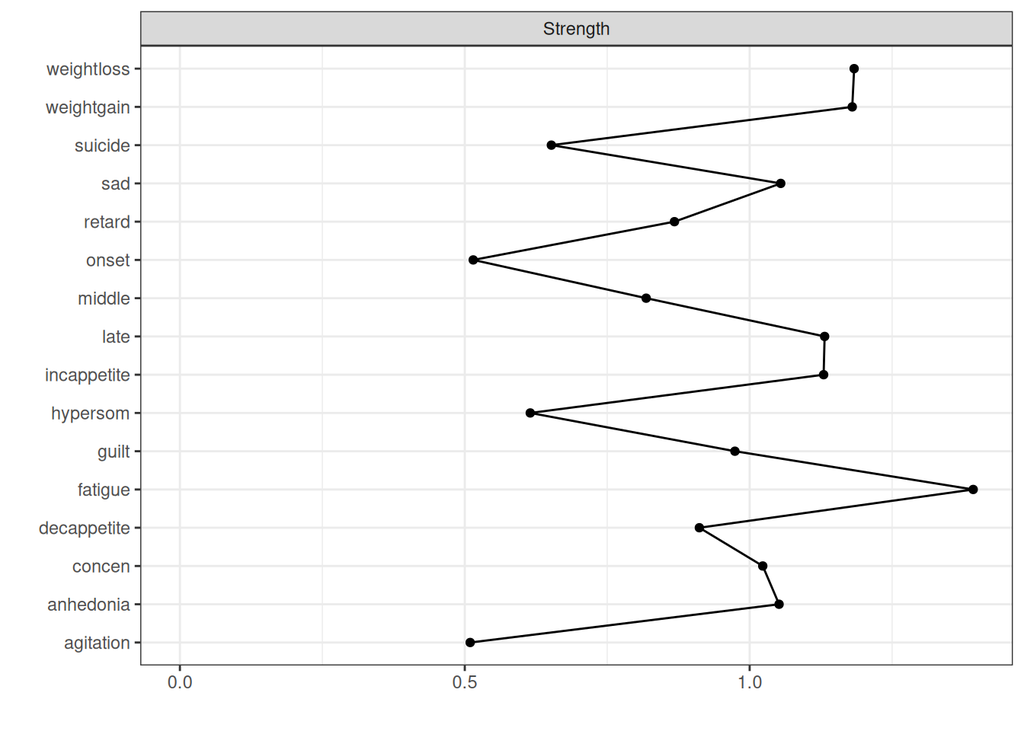

```r
# EI
plot(ei_results$step1)
# Strength
centralityPlot(results_dep, include = "Strength")
```

- 負のエッジがあるweightgainなどはEIが低くなる

## ブリッジ中心性

- ネットワーク内に複数のクラスターが含まれる場合、あるノードと他のクラスターのノード群との間にどれだけ強い接続があるかを示す指標
- Rogersデータには、うつとOCDの症状が含まれているため、ブリッジ中心性を検証してみる(OCDはY-BOCSの10項目、日本語版は[こちら](https://jpsad.jp/files/JSARD_recommended_scale_Y-BOCS.pdf)を参照)
- obtime: 強迫観念に費やされる時間
- obinterfer: 強迫観念による支障
- obdistress: 強迫観念によって引き起こされる苦痛
- obresist: 強迫観念に抵抗することの困難さ
- obcontrol: 強迫観念をコントロールすることの困難さ
- comptime: 強迫行為に費やされる時間
- compinterf: 強迫行為による支障
- compdis: 強迫行為によって引き起こされる苦痛
- compresis: 強迫行為に抵抗することの困難さ
- compcont: 強迫行為をコントロールすることの困難さ

## ネットワークの推定

- ２つのクラスター（コミュニティ）を定義して、ネットワーク推定とプロットを行う

```r
data_dep_ocd <- Rogers
node_names <- colnames(data_dep_ocd)
# コミュニティの定義
communities <- c( rep("Depression", 16), rep("OCD", 10) )

results_dep_ocd <- estimateNetwork(data_dep_ocd,default = "EBICglasso", corMethod = "cor_auto")

plot(results_dep_ocd, theme = "colorblind", cut = 0,layout = "spring",labels = node_names,groups = communities,legend = TRUE)
```

## ネットワーク図

- 症状できれいに分かれている
- ２つのクラスターを繋ぐ症状がある

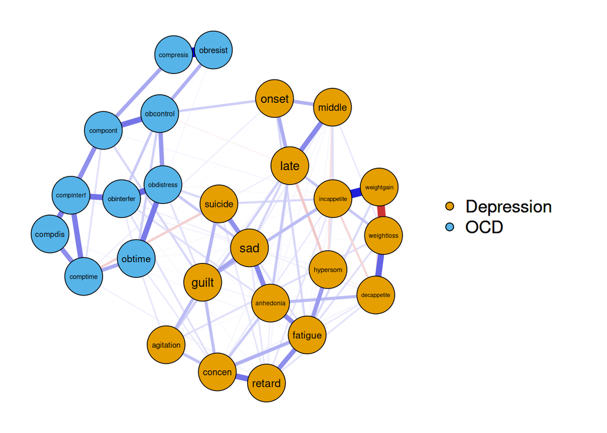

## ブリッジ中心性の計算

- ブリッジ中心性は、networktoolsパッケージのbridge()関数で計算できる

```r
# ブリッジ中心性の計算
results_bridge <- bridge(results_dep_ocd$graph, communities = communities)

# ブリッジ中心性のプロット
plot(results_bridge, include = c("Bridge Strength", "Bridge Expected Influence (1-step)"))
```

## ブリッジ中心性について

- EIもStrengthもobdistress（強迫観念によって引き起こされる苦痛）が最もブリッジ中心性が高い

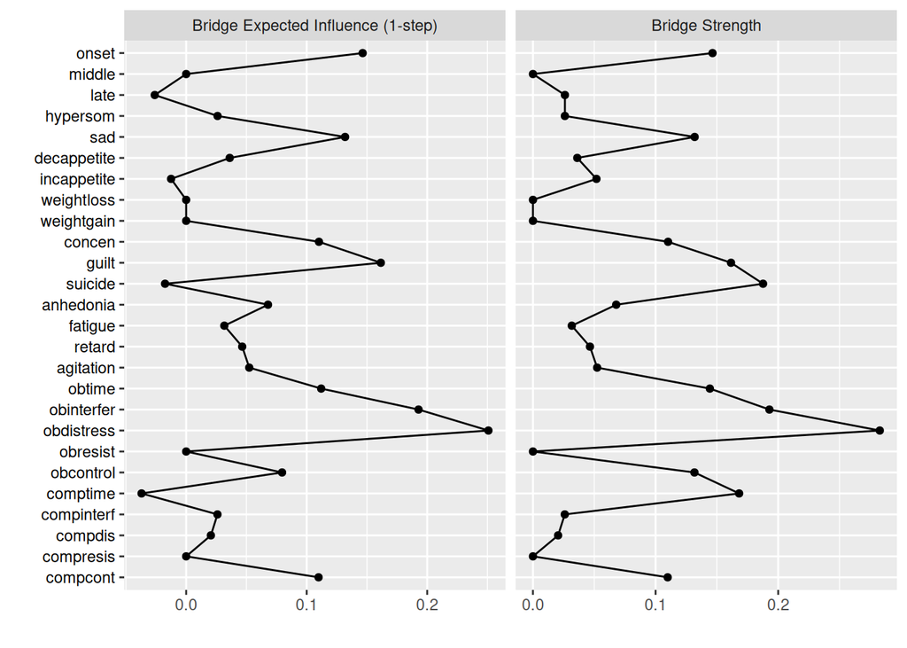

## ネットワーク比較検定

- ２群間でネットワーク構造が異なるかどうかを検定する方法（２群のデータは、同一の母集団ネットワークから得られた実現値かどうか検定）
- 並び替え検定（ノンパラメトリック検定、複数の群のデータからランダムに並べ替えを繰り返し、得られた検定統計量の分布から検定する）を用いる

## QIDS合計点のヒストグラム

- QIDSの合計点を計算してヒストグラムを描く(連続的な分布をしているが、人数比的に「重度」のカットオフ値の16点でグループ分けできそう)

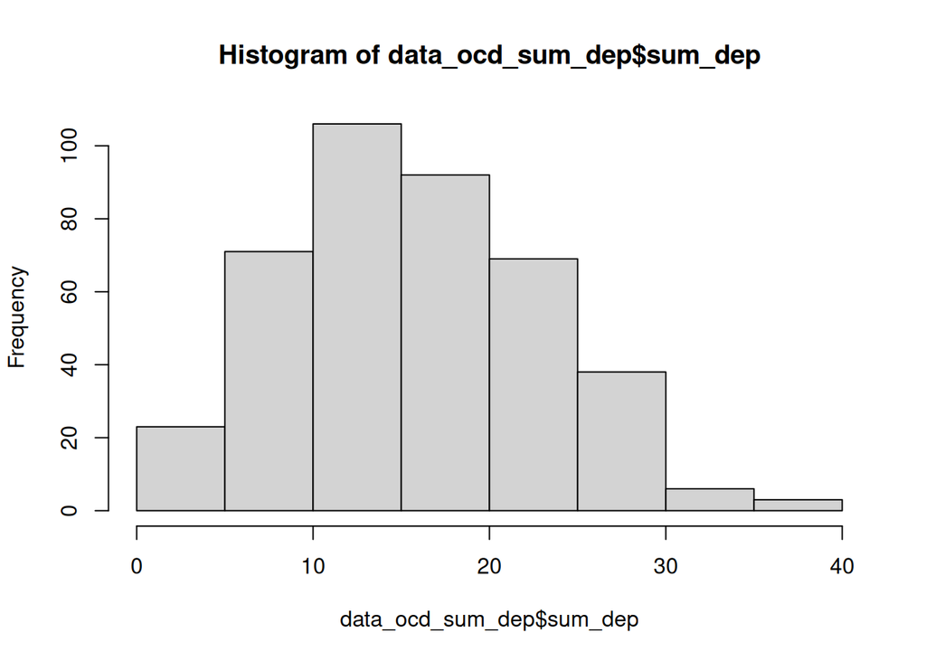

```r
data_ocd_sum_dep <- Rogers %>%
  mutate(sum_dep = rowSums(across(onset:agitation))) %>%
  select(obtime:sum_dep)

hist(data_ocd_sum_dep$sum_dep)
```

## うつ症状の高群・低群の設定

- QIDSは15点以下(200名)と16点以上(208名)でグループ分けする

```r
data_ocd_H_dep <- data_ocd_sum_dep %>%
  filter(sum_dep >=16) %>%
  select(-sum_dep)

data_ocd_L_dep <- data_ocd_sum_dep %>%
  filter(sum_dep <=15) %>%
  select(-sum_dep)

node_names <- colnames(data_ocd_H_dep)
```

## ネットワークの推定とプロット

- それぞれ群についてネットワーク推定した上で、プロットする際のレイアウトをaverageLayout関数で調整する

```r
# ネットワークの推定
results_ocd_H_dep <- estimateNetwork(data_ocd_H_dep,default = "EBICglasso", corMethod = "cor_auto")
results_ocd_L_dep <- estimateNetwork(data_ocd_L_dep,default = "EBICglasso", corMethod = "cor_auto")
# レイアウトを調整してプロット
avg_layout <- averageLayout(results_ocd_H_dep, results_ocd_L_dep)
plot(results_ocd_H_dep, layout = avg_layout, theme = "colorblind", cut = 0,labels = node_names)
plot(results_ocd_L_dep, layout = avg_layout, theme = "colorblind", cut = 0,labels = node_names)
```

## ネットワーク図の比較

- うつ症状の高群（左）・低群（右）。視覚的にはエッジの有無や強さに違いはありそう？

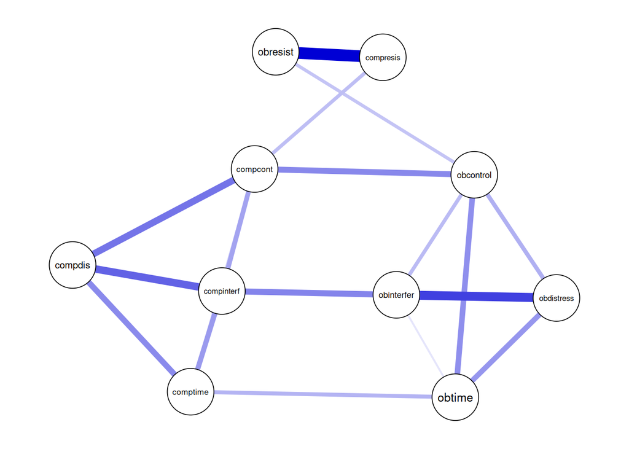

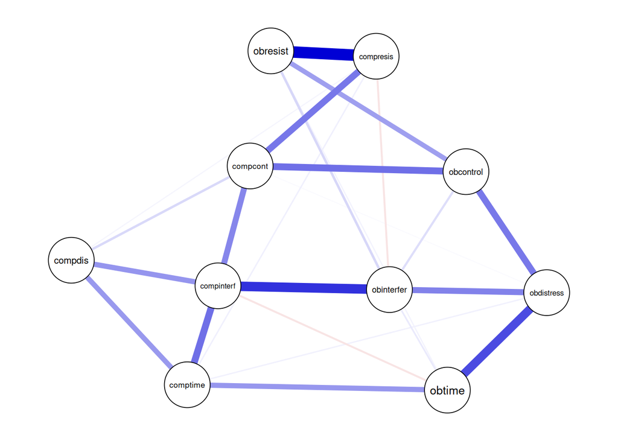

## ネットワーク比較検定

- NetworkComparisonTestパッケージのNCT()関数で計算する（計算には時間がかかる）。itは並び替えの回数、test.edgesでエッジごとの検定をするか、edgesで”all”とすると全てのエッジで検定、p.adjust.methodsで多重比較補正の方法を指定（今回は補正しない）

```r
results_NCT <- NCT(results_ocd_H_dep, results_ocd_L_dep,
                     it = 1000,
                     test.edges = TRUE,
                     edges = "all",
                     p.adjust.methods = "none",
                     progressbar = TRUE)
```

## ネットワーク比較検定結果

- 大域的強度検定（エッジの重みの絶対値を全て足し合わせた大域的強度の差異が認められるか、接続が密かどうかの検討になる）

```r
results_NCT$glstrinv.pval
```

```
[1] 0.5854146
```

- オムニバス検定(ネットワーク間で少なくとも１本以上のエッジについて差異が認められるか)

```r
results_NCT$nwinv.pval
```

```
[1] 0.4145854
```

- 群間にネットワークの違いは認められなかった

## ネットワーク比較検定結果

- エッジごとの検定(各エッジについて有意な差があるかどうか、特定のエッジについての群間差の仮説がある場合、もしくはオムニバス検定で有意な際に確認する)

```r
results_NCT$einv.pval
```

```
Var1       Var2    p-value Test statistic E
11     obtime obinterfer 0.91508492       0.01395998
21     obtime obdistress 0.19780220       0.15035875
22 obinterfer obdistress 0.23376623       0.15335918
31     obtime   obresist 0.78121878       0.02463312
32 obinterfer   obresist 0.16583417       0.08403311
33 obdistress   obresist 1.00000000       0.00000000
41     obtime  obcontrol 0.02797203       0.24415656
42 obinterfer  obcontrol 0.52847153       0.07837107
43 obdistress  obcontrol 0.34365634       0.11314565
44   obresist  obcontrol 0.43556444       0.07361563
51     obtime   comptime 0.63436563       0.05730800
52 obinterfer   comptime 1.00000000       0.00000000
53 obdistress   comptime 0.25574426       0.02856884
54   obresist   comptime 1.00000000       0.00000000
```

[output cut: 31 more lines]

## Isingモデル

- 変数が2値の場合はIsingモデルを用いる
- Isingモデル用パッケージを読み込んで、RogersデータのQIDSを２値に変換する（binarize()関数で０なら０、１以上なら１に）

```r
data_dep_bi <- data_dep %>%
  select(-incappetite, -weightgain) %>%
  bootnet::binarize(split = 1)

node_names_bi <- colnames(data_dep_bi)
```

## Isingモデルの推定

```r
results_Ising <- estimateNetwork(data_dep_bi, 'IsingSampler')
plot(results_Ising)
```

## Isingモデルのネットワーク図

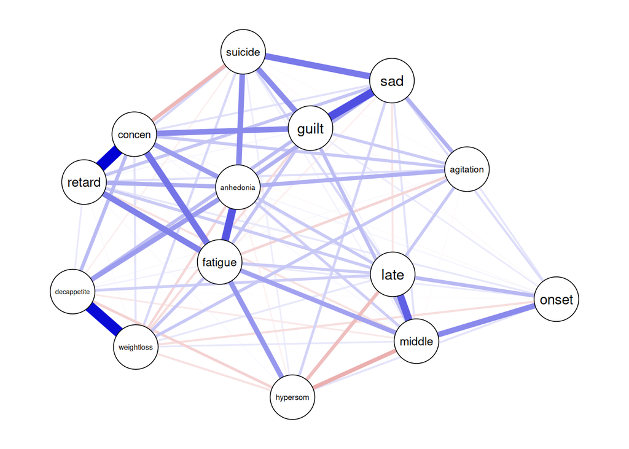

## 中心性指標

```r
centralityPlot(results_Ising, include = "Strength",labels = node_names_bi)
```

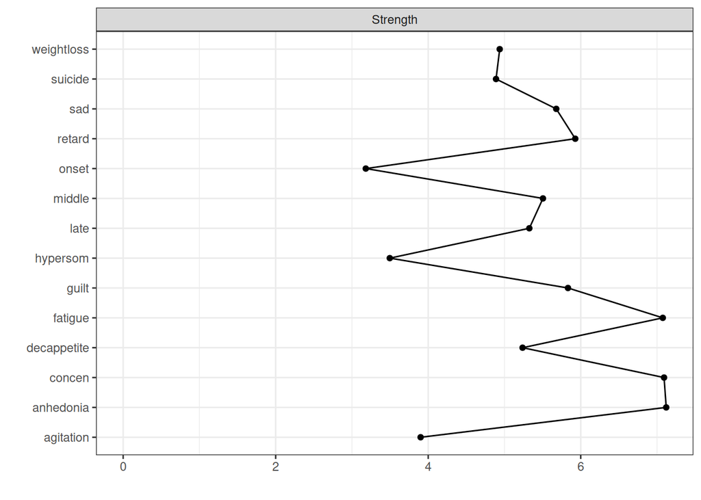

## IsingFitの推定結果の取り出し

- Isingモデルの推定結果は、次の「ネットワークシミュレーション」で用いる
- IsingFitの重みはgraphに入っており、閾値はinterceptsに入っているので取り出しておく

```r
weights <- results_Ising$graph
thresholds <- results_Ising$intercepts
```

# ネットワークシミュレーション

## ネットワークシミュレーション

- DSM-III-TRに基づく大うつ病の横断データ(8973名)から症状ネットワークを推定
- シミュレーションで、ネットワーク結合を強めるパラメータ$c$の値が症状全体の活性化につながることを示した(Cramer et al. 2016)

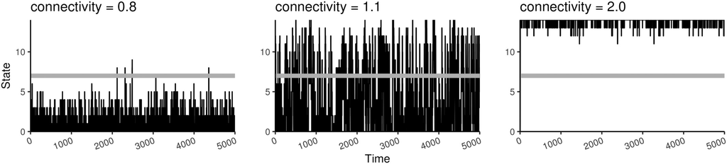

## 治療とネットワーク密度

- Cramer et al. (2016) の結果から、症状ネットワークの接続が強いと、症状が悪化しやすいことが示唆された
- しかし、心理療法の介入研究では、症状が改善しても接続が強まっていることも(Höller et al. 2022)
- ネットワークに症状以外の治療的な要素を入れることで、どの症状を標的にすれば効果が得られるかシミュレーションできるのでは？

→ Omizu and Kunisato (2024) は、治療的な要素を表すノードを追加したシミュレーションを実施

## 単独症状への介入

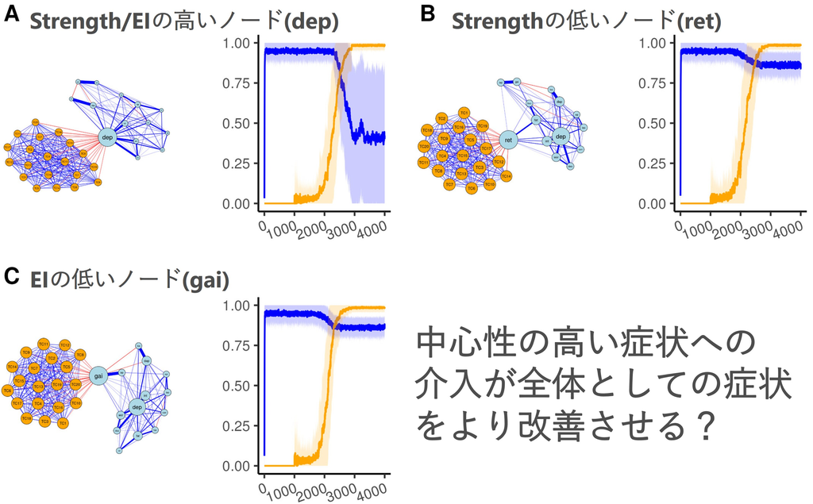

## 複数症状への介入

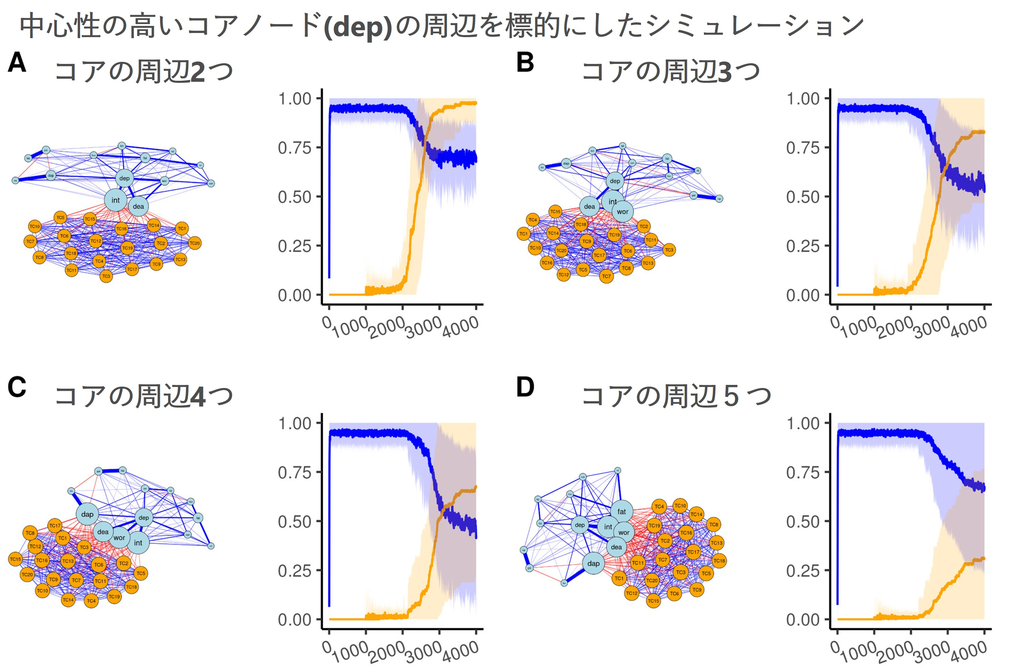

## psynetsimパッケージによるシミュレーション

- 研究室の[大水拓海さん](https://psytakumio.github.io/takumiomizu/index.html)が論文で用いたコードをRパッケージ化している([psynetsimパッケージ](https://github.com/TakumiOmizu/psynetsim))
- 以降では、psynetsimパッケージを用いてシミュレーションを行う。最初に、乱数のシードを固定する

```r
library(psynetsim)
set.seed(1234)
```